# German Credit Data Set Analysis

Utku Erdogan

May 8, 2018

#### INDEX

##### 1.Introduction

##### 1.1 Purpose of Project

##### 2.Data

##### 2.1.Structure of Data

##### 2.2.Data Visualization

##### 2.3.Data Manipulation

##### 2.4.Data Analysis

##### 3.Model

##### 3.1.Insert Population

##### 3.2.Implementation Modelling

##### 3.3.Result of Modelling

##### 4.Result

##### 5.Resource

#### 1.Introduction

##### 1.1 Purpose of Project

German Credit dataset will be implemented logistic regression modelling which predict a target as “Good” and “Bad” on Kaggle website. Explanatory variables will be used in modelling. Methodology will be used Stepwise.

#### 2.Data

##### 2.1.Structure of Data

```r
library(knitr)
kable(head(german_credit_data <- read.csv(file="C:/Users/U085461/Documents/R/Project/german_credit_data.csv")))
```

| X | Age | Sex | Job | Housing | Saving.accounts | Checking.account | Credit.amount | Duration | Purpose | Risk |
| --- | --- | --- | --- | --- | --- | --- | --- | --- | --- | --- |
| 0 | 67 | male | 2 | own | NA | little | 1169 | 6 | radio/TV | good |
| 1 | 22 | female | 2 | own | little | moderate | 5951 | 48 | radio/TV | bad |
| 2 | 49 | male | 1 | own | little | NA | 2096 | 12 | education | good |
| 3 | 45 | male | 2 | free | little | little | 7882 | 42 | furniture/equipment | good |
| 4 | 53 | male | 2 | free | little | little | 4870 | 24 | car | bad |
| 5 | 35 | male | 1 | free | NA | NA | 9055 | 36 | education | good |

Changing name of first column

```r
names(german_credit_data)[1]<-"ID"
```

It shows structure of data

```r
class(german_credit_data)
```

```
## [1] "data.frame"
```

```r
dim(german_credit_data)
```

```
## [1] 1000   11
```

```r
str(german_credit_data)
```

```
## 'data.frame':    1000 obs. of  11 variables:
##  $ ID              : int  0 1 2 3 4 5 6 7 8 9 ...
##  $ Age             : int  67 22 49 45 53 35 53 35 61 28 ...
##  $ Sex             : Factor w/ 2 levels "female","male": 2 1 2 2 2 2 2 2 2 2 ...
##  $ Job             : int  2 2 1 2 2 1 2 3 1 3 ...
##  $ Housing         : Factor w/ 3 levels "free","own","rent": 2 2 2 1 1 1 2 3 2 2 ...
##  $ Saving.accounts : Factor w/ 4 levels "little","moderate",..: NA 1 1 1 1 NA 3 1 4 1 ...
##  $ Checking.account: Factor w/ 3 levels "little","moderate",..: 1 2 NA 1 1 NA NA 2 NA 2 ...
##  $ Credit.amount   : int  1169 5951 2096 7882 4870 9055 2835 6948 3059 5234 ...
##  $ Duration        : int  6 48 12 42 24 36 24 36 12 30 ...
##  $ Purpose         : Factor w/ 8 levels "business","car",..: 6 6 4 5 2 4 5 2 6 2 ...
##  $ Risk            : Factor w/ 2 levels "bad","good": 2 1 2 2 1 2 2 2 2 1 ...
```

```r
summary(german_credit_data)
```

```
##        ID             Age            Sex           Job        Housing
##  Min.   :  0.0   Min.   :19.00   female:310   Min.   :0.000   free:108
##  1st Qu.:249.8   1st Qu.:27.00   male  :690   1st Qu.:2.000   own :713
##  Median :499.5   Median :33.00                Median :2.000   rent:179
##  Mean   :499.5   Mean   :35.55                Mean   :1.904
##  3rd Qu.:749.2   3rd Qu.:42.00                3rd Qu.:2.000
##  Max.   :999.0   Max.   :75.00                Max.   :3.000
##
##    Saving.accounts Checking.account Credit.amount      Duration
##  little    :603    little  :274     Min.   :  250   Min.   : 4.0
##  moderate  :103    moderate:269     1st Qu.: 1366   1st Qu.:12.0
##  quite rich: 63    rich    : 63     Median : 2320   Median :18.0
##  rich      : 48    NA's    :394     Mean   : 3271   Mean   :20.9
##  NA's      :183                     3rd Qu.: 3972   3rd Qu.:24.0
##                                     Max.   :18424   Max.   :72.0
##
##                 Purpose      Risk
##  car                :337   bad :300
##  radio/TV           :280   good:700
##  furniture/equipment:181
##  business           : 97
##  education          : 59
##  repairs            : 22
##  (Other)            : 24
```

It shows null rows on data

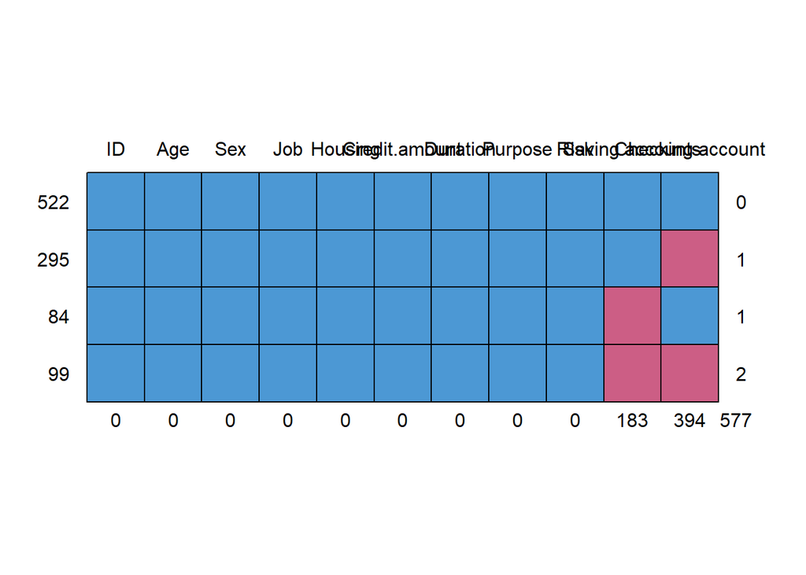

```
##     ID Age Sex Job Housing Credit.amount Duration Purpose Risk
## 522  1   1   1   1       1             1        1       1    1
## 295  1   1   1   1       1             1        1       1    1
## 84   1   1   1   1       1             1        1       1    1
## 99   1   1   1   1       1             1        1       1    1
##      0   0   0   0       0             0        0       0    0
##     Saving.accounts Checking.account
## 522               1                1   0
## 295               1                0   1
## 84                0                1   1
## 99                0                0   2
##                 183              394 577
```

```r
library(mice)
library(lattice)

md.pattern(german_credit_data)
```

522 rows is not null

##### 2.2.Data Visualization

Numeric variables show distribution. The histograms show on below side

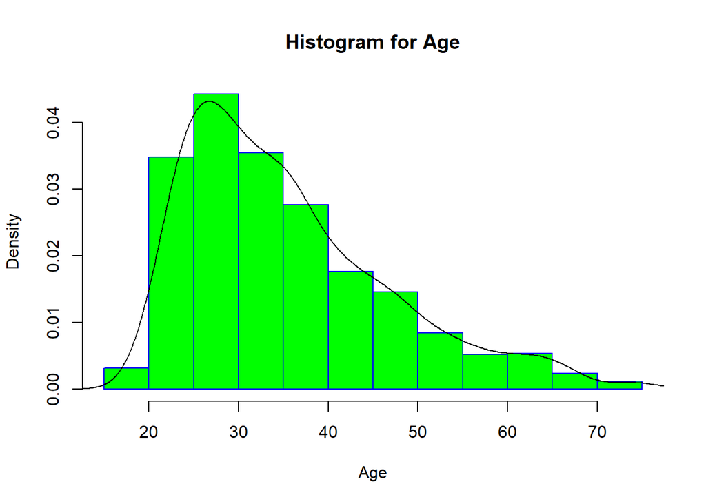

```r
german_credit_data_age<-hist(german_credit_data$Age,
                             main="Histogram for Age",
                             xlab="Age",
                             border="blue",
                             col="green",
                             prob = TRUE)
lines(density(german_credit_data$Age))
```

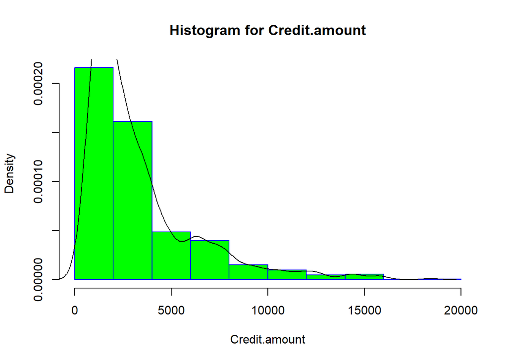

```r
german_credit_data_credit.amount<-hist(german_credit_data$Credit.amount,
                                       main="Histogram for Credit.amount",
                                       xlab="Credit.amount",
                                       border="blue",
                                       col="green",
                                       prob = TRUE)
lines(density(german_credit_data$Credit.amount))
```

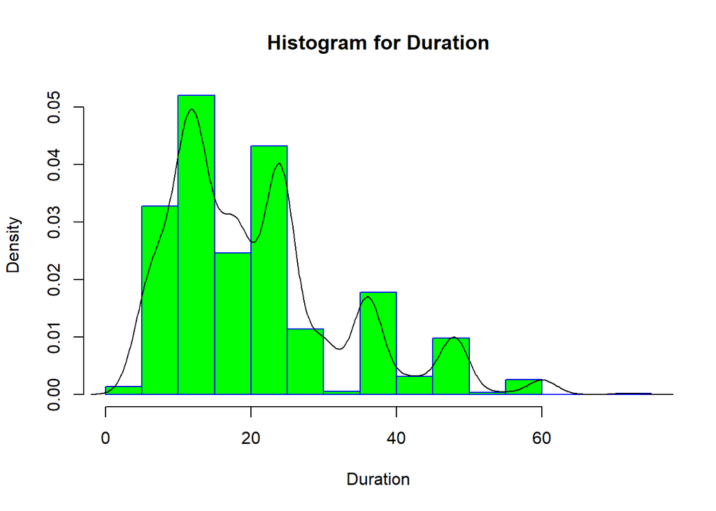

```r
german_credit_data_duration<-hist(german_credit_data$Duration,
                                  main="Histogram for Duration",
                                  xlab="Duration",
                                  border="blue",
                                  col="green",
                                  prob = TRUE)
lines(density(german_credit_data$Duration))
```

Categorical variables show with bar chart on below side

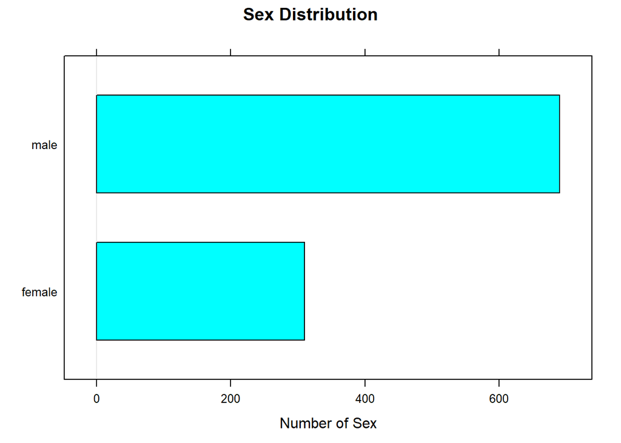

```r
barchart(table(german_credit_data$Sex),
         main="Sex Distribution",
         xlab="Number of Sex")
```

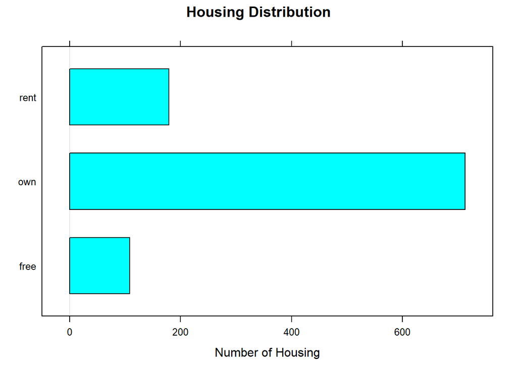

```r
barchart(table(german_credit_data$Housing),
         main="Housing Distribution",
         xlab="Number of Housing")
```

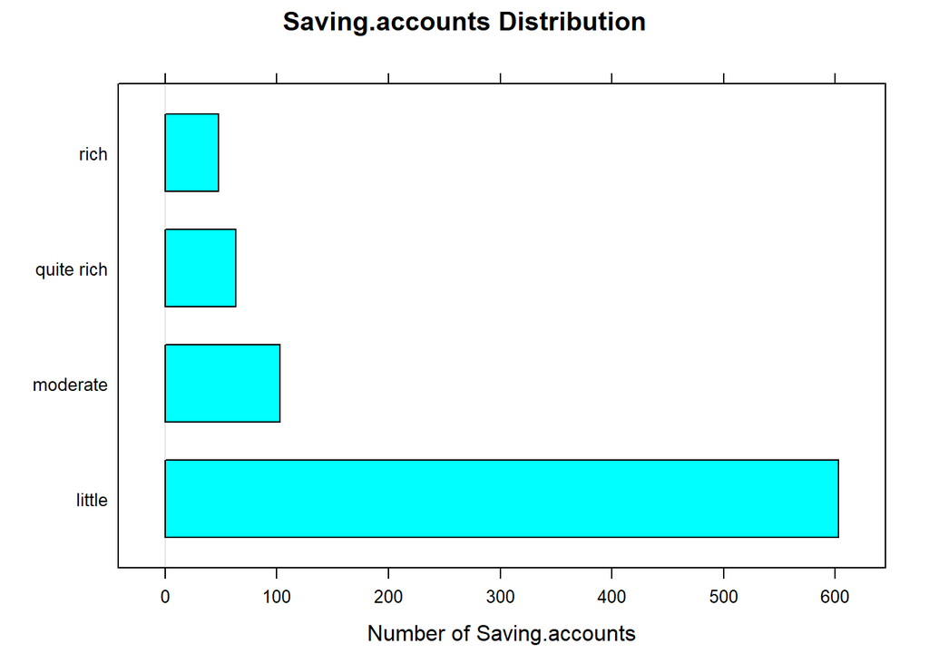

```r
barchart(table(german_credit_data$Saving.accounts),
         main="Saving.accounts Distribution",
         xlab="Number of Saving.accounts")
```

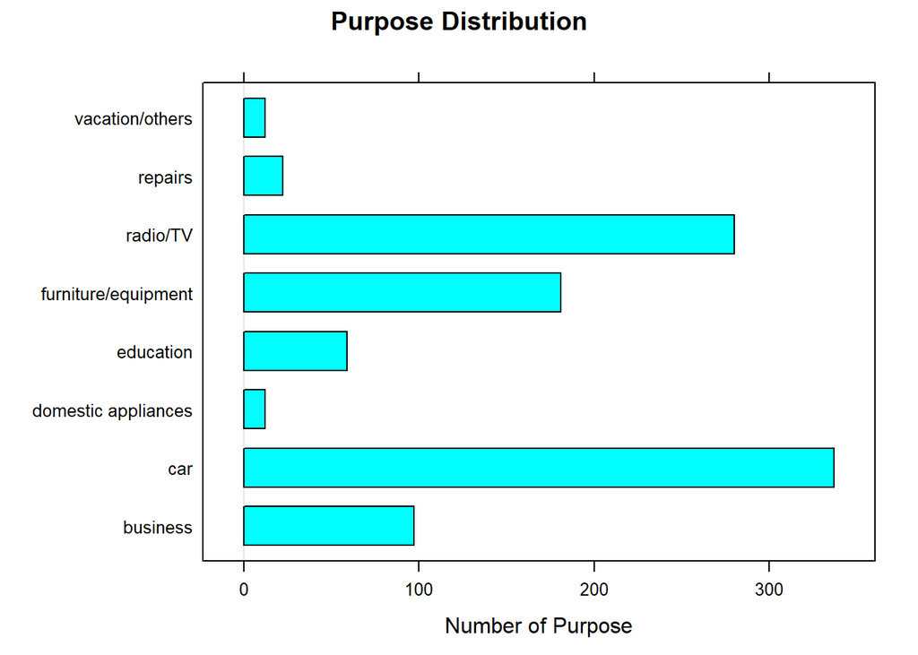

```r
barchart(table(german_credit_data$Purpose),
         main="Purpose Distribution",
         xlab="Number of Purpose")
```

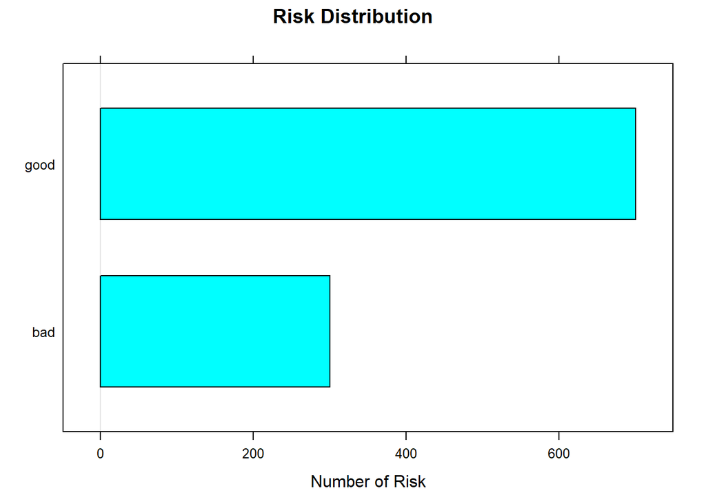

```r
barchart(table(german_credit_data$Risk),
         main="Risk Distribution",
         xlab="Number of Risk")
```

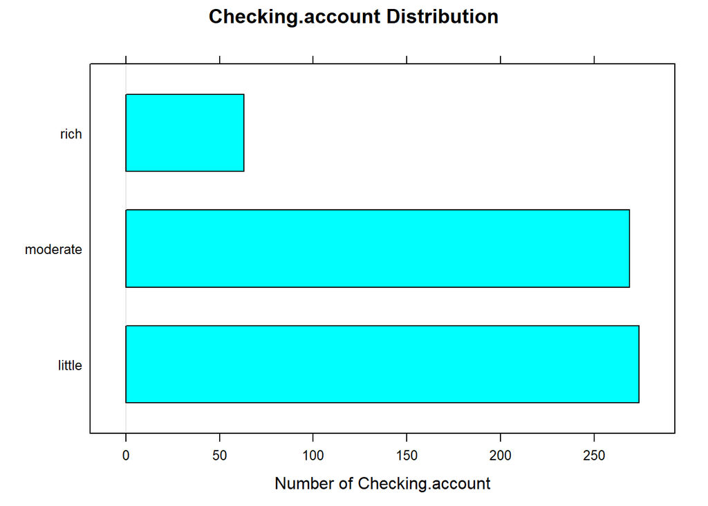

```r
barchart(table(german_credit_data$Checking.account),
         main="Checking.account Distribution",
         xlab="Number of Checking.account")
```

##### 2.3.Data Manipulation

```r
library(dplyr)
kable(head(df <- filter(german_credit_data,is.na(Checking.account))))
```

| ID | Age | Sex | Job | Housing | Saving.accounts | Checking.account | Credit.amount | Duration | Purpose | Risk |
| --- | --- | --- | --- | --- | --- | --- | --- | --- | --- | --- |
| 2 | 49 | male | 1 | own | little | NA | 2096 | 12 | education | good |
| 5 | 35 | male | 1 | free | NA | NA | 9055 | 36 | education | good |
| 6 | 53 | male | 2 | own | quite rich | NA | 2835 | 24 | furniture/equipment | good |
| 8 | 61 | male | 1 | own | rich | NA | 3059 | 12 | radio/TV | good |
| 16 | 53 | male | 2 | own | NA | NA | 2424 | 24 | radio/TV | good |
| 19 | 31 | male | 2 | own | quite rich | NA | 3430 | 24 | radio/TV | good |

```r
kable(head(german_credit_data_v1 <- anti_join(german_credit_data,df,by="ID")))
```

| ID | Age | Sex | Job | Housing | Saving.accounts | Checking.account | Credit.amount | Duration | Purpose | Risk |
| --- | --- | --- | --- | --- | --- | --- | --- | --- | --- | --- |
| 0 | 67 | male | 2 | own | NA | little | 1169 | 6 | radio/TV | good |
| 1 | 22 | female | 2 | own | little | moderate | 5951 | 48 | radio/TV | bad |
| 3 | 45 | male | 2 | free | little | little | 7882 | 42 | furniture/equipment | good |
| 4 | 53 | male | 2 | free | little | little | 4870 | 24 | car | bad |
| 7 | 35 | male | 3 | rent | little | moderate | 6948 | 36 | car | good |
| 9 | 28 | male | 3 | own | little | moderate | 5234 | 30 | car | bad |

```r
kable(head(df_1 <- filter(german_credit_data,is.na(Saving.accounts))))
```

| ID | Age | Sex | Job | Housing | Saving.accounts | Checking.account | Credit.amount | Duration | Purpose | Risk |
| --- | --- | --- | --- | --- | --- | --- | --- | --- | --- | --- |
| 0 | 67 | male | 2 | own | NA | little | 1169 | 6 | radio/TV | good |
| 5 | 35 | male | 1 | free | NA | NA | 9055 | 36 | education | good |
| 16 | 53 | male | 2 | own | NA | NA | 2424 | 24 | radio/TV | good |
| 17 | 25 | male | 2 | own | NA | little | 8072 | 30 | business | good |
| 24 | 26 | male | 2 | own | NA | NA | 2069 | 10 | furniture/equipment | good |
| 33 | 57 | male | 1 | rent | NA | NA | 1264 | 12 | business | good |

```r
kable(head(german_credit_data_v2 <- anti_join(german_credit_data_v1,df_1,by="ID")))
```

| ID | Age | Sex | Job | Housing | Saving.accounts | Checking.account | Credit.amount | Duration | Purpose | Risk |
| --- | --- | --- | --- | --- | --- | --- | --- | --- | --- | --- |
| 1 | 22 | female | 2 | own | little | moderate | 5951 | 48 | radio/TV | bad |
| 3 | 45 | male | 2 | free | little | little | 7882 | 42 | furniture/equipment | good |
| 4 | 53 | male | 2 | free | little | little | 4870 | 24 | car | bad |
| 7 | 35 | male | 3 | rent | little | moderate | 6948 | 36 | car | good |
| 9 | 28 | male | 3 | own | little | moderate | 5234 | 30 | car | bad |
| 10 | 25 | female | 2 | rent | little | moderate | 1295 | 12 | car | bad |

```r
str(german_credit_data_v2)
```

```
## 'data.frame':    522 obs. of  11 variables:
##  $ ID              : int  1 3 4 7 9 10 11 12 13 14 ...
##  $ Age             : int  22 45 53 35 28 25 24 22 60 28 ...
##  $ Sex             : Factor w/ 2 levels "female","male": 1 2 2 2 2 1 1 1 2 1 ...
##  $ Job             : int  2 2 2 3 3 2 2 2 1 2 ...
##  $ Housing         : Factor w/ 3 levels "free","own","rent": 2 1 1 3 2 3 3 2 2 3 ...
##  $ Saving.accounts : Factor w/ 4 levels "little","moderate",..: 1 1 1 1 1 1 1 1 1 1 ...
##  $ Checking.account: Factor w/ 3 levels "little","moderate",..: 2 1 1 2 2 2 1 2 1 1 ...
##  $ Credit.amount   : int  5951 7882 4870 6948 5234 1295 4308 1567 1199 1403 ...
##  $ Duration        : int  48 42 24 36 30 12 48 12 24 15 ...
##  $ Purpose         : Factor w/ 8 levels "business","car",..: 6 5 2 2 2 2 1 6 2 2 ...
##  $ Risk            : Factor w/ 2 levels "bad","good": 1 2 1 2 1 1 1 2 1 2 ...
```

```r
library(plyr)
german_credit_data_v2$Risk<- revalue(german_credit_data_v2$Risk, c("bad"="1"))
german_credit_data_v2$Risk<- revalue(german_credit_data_v2$Risk, c("good"="0"))
```

German_credit_data_v2 is last updated of data

##### 2.4.Data Analysis

###### 2.4.1.Correlation Analysis

All numeric variables is done correlation analysis. When correlation value is greater than 0.75, this variable is excluded.

```r
library(corrplot)
library(RColorBrewer)
#correlation
x <- cor(german_credit_data_v2[,unlist(lapply(german_credit_data_v2, is.numeric))])
x
```

```
##                         ID          Age         Job Credit.amount
## ID             1.000000000 -0.034808877 -0.08164671   -0.02362967
## Age           -0.034808877  1.000000000  0.03977068    0.08201393
## Job           -0.081646712  0.039770678  1.00000000    0.33472091
## Credit.amount -0.023629666  0.082013934  0.33472091    1.00000000
## Duration       0.006486812  0.001548979  0.20079399    0.61329786
##                  Duration
## ID            0.006486812
## Age           0.001548979
## Job           0.200793992
## Credit.amount 0.613297863
## Duration      1.000000000
```

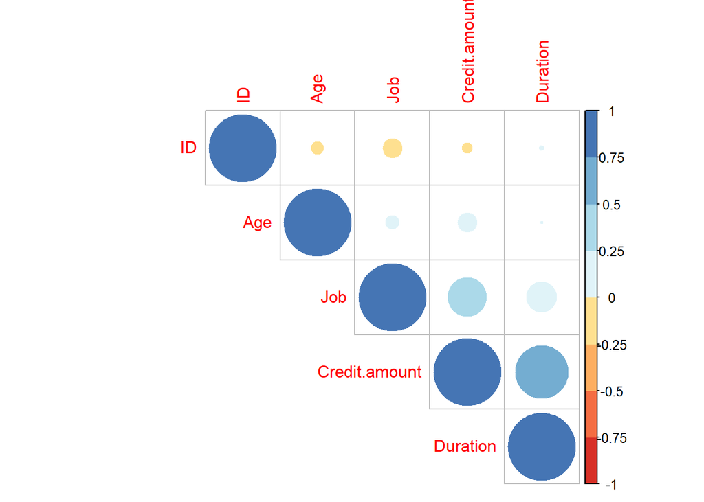

```r
#correlation visualization
corrplot(x, type="upper", order="hclust",
         col=brewer.pal(n=8, name="RdYlBu"))
```

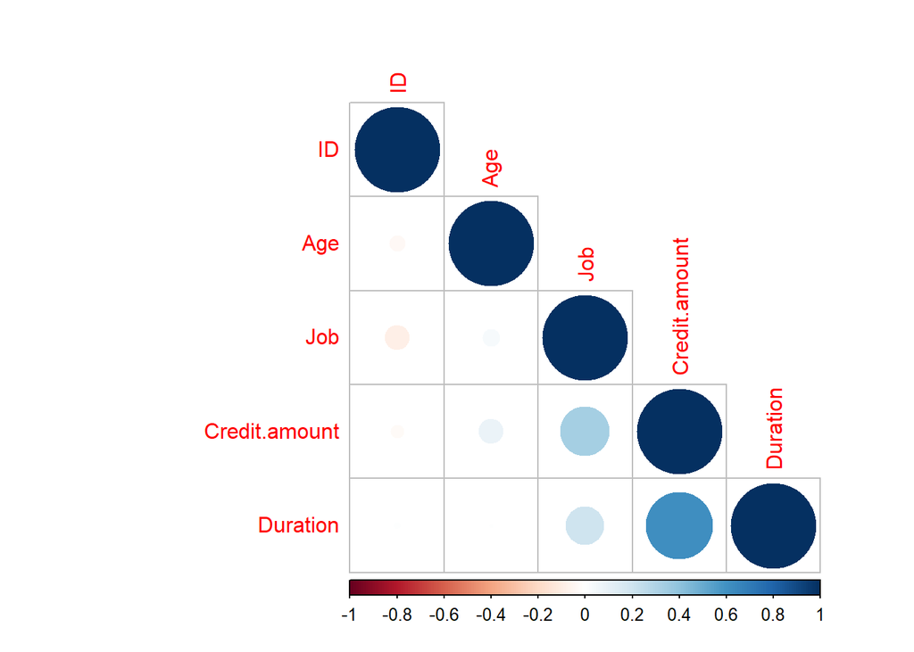

```r
corrplot(x,type="lower")
```

#### 3.MODEL

##### 3.1.Insert Population

```r
require(caTools)
set.seed(123)
sample = sample.split(german_credit_data_v2,SplitRatio = 0.70)
train =subset(german_credit_data_v2,sample ==TRUE)
test=subset(german_credit_data_v2, sample==FALSE)
```

##### 3.2.Implementation Modelling

It is set logistic regression modelling on cleaning dataset. Results show on below side.

```r
full<-glm(Risk~., family=binomial, data=train)
summary(full)
```

```
##
## Call:
## glm(formula = Risk ~ ., family = binomial, data = train)
##
## Deviance Residuals:
##     Min       1Q   Median       3Q      Max
## -2.0788  -1.0179   0.4902   0.9636   2.1310
##
## Coefficients:
##                              Estimate Std. Error z value Pr(>|z|)
## (Intercept)                 1.077e+00  1.012e+00   1.064   0.2873
## ID                         -7.545e-04  4.304e-04  -1.753   0.0795 .
## Age                         1.192e-02  1.232e-02   0.967   0.3333
## Sexmale                     2.897e-01  2.685e-01   1.079   0.2806
## Job                        -3.193e-03  1.965e-01  -0.016   0.9870
## Housingown                  5.568e-01  4.406e-01   1.264   0.2063
## Housingrent                 1.730e-01  5.066e-01   0.342   0.7327
## Saving.accountsmoderate     1.305e-01  4.020e-01   0.325   0.7455
## Saving.accountsquite rich   4.400e-01  6.094e-01   0.722   0.4703
## Saving.accountsrich         1.358e+00  6.924e-01   1.961   0.0499 *
## Checking.accountmoderate    2.111e-01  2.904e-01   0.727   0.4674
## Checking.accountrich        8.991e-01  4.420e-01   2.034   0.0420 *
## Credit.amount              -3.775e-05  6.032e-05  -0.626   0.5314
## Duration                   -5.518e-02  1.342e-02  -4.113 3.91e-05 ***
## Purposecar                 -7.304e-01  4.706e-01  -1.552   0.1207
## Purposedomestic appliances -1.471e+00  1.398e+00  -1.052   0.2929
## Purposeeducation           -1.524e+00  6.993e-01  -2.179   0.0293 *
## Purposefurniture/equipment -2.163e-01  4.934e-01  -0.438   0.6611
## Purposeradio/TV            -4.383e-01  4.841e-01  -0.905   0.3653
## Purposerepairs             -9.513e-01  8.535e-01  -1.115   0.2650
## Purposevacation/others     -7.503e-01  1.433e+00  -0.524   0.6005
## ---
## Signif. codes:  0 '***' 0.001 '**' 0.01 '*' 0.05 '.' 0.1 ' ' 1
##
## (Dispersion parameter for binomial family taken to be 1)
##
##     Null deviance: 458.79  on 331  degrees of freedom
## Residual deviance: 390.20  on 311  degrees of freedom
## AIC: 432.2
##
## Number of Fisher Scoring iterations: 4
```

When Vif values is greater than 2.5, this variable is excluded.

```r
#vif values
car::vif(full)
```

```
##                      GVIF Df GVIF^(1/(2*Df))
## ID               1.049626  1        1.024512
## Age              1.272725  1        1.128151
## Sex              1.099623  1        1.048629
## Job              1.191781  1        1.091687
## Housing          1.376603  2        1.083184
## Saving.accounts  1.189428  3        1.029334
## Checking.account 1.323514  2        1.072586
## Credit.amount    1.681776  1        1.296833
## Duration         1.564761  1        1.250904
## Purpose          1.661477  7        1.036930
```

```r
#ok
```

All Vif of values is lower than 2.5, so all variable is not excluded

Selected variables; -Saving.accounts -Duration -Checking.account -Purpose

It will be set modelling again on these variables

```r
full1<-glm(Risk~Saving.accounts+Duration+Checking.account+Purpose, family=binomial, data=train)
summary(full1)
```

```
##
## Call:
## glm(formula = Risk ~ Saving.accounts + Duration + Checking.account +
##     Purpose, family = binomial, data = train)
##
## Deviance Residuals:
##     Min       1Q   Median       3Q      Max
## -2.0310  -1.0956   0.5537   0.9745   2.0612
##
## Coefficients:
##                            Estimate Std. Error z value Pr(>|z|)
## (Intercept)                 1.73889    0.52118   3.336 0.000849 ***
## Saving.accountsmoderate     0.07364    0.39222   0.188 0.851078
## Saving.accountsquite rich   0.36274    0.58151   0.624 0.532769
## Saving.accountsrich         1.35024    0.67806   1.991 0.046446 *
## Duration                   -0.06093    0.01105  -5.513 3.54e-08 ***
## Checking.accountmoderate    0.20595    0.27699   0.744 0.457174
## Checking.accountrich        0.91887    0.43377   2.118 0.034148 *
## Purposecar                 -0.76596    0.45140  -1.697 0.089728 .
## Purposedomestic appliances -1.11434    1.38566  -0.804 0.421288
## Purposeeducation           -1.63918    0.67223  -2.438 0.014752 *
## Purposefurniture/equipment -0.32032    0.47265  -0.678 0.497959
## Purposeradio/TV            -0.36195    0.46388  -0.780 0.435239
## Purposerepairs             -0.76208    0.80849  -0.943 0.345891
## Purposevacation/others     -0.57747    1.36498  -0.423 0.672250
## ---
## Signif. codes:  0 '***' 0.001 '**' 0.01 '*' 0.05 '.' 0.1 ' ' 1
##
## (Dispersion parameter for binomial family taken to be 1)
##
##     Null deviance: 458.79  on 331  degrees of freedom
## Residual deviance: 399.15  on 318  degrees of freedom
## AIC: 427.15
##
## Number of Fisher Scoring iterations: 4
```

```r
full2<-glm(Risk~Saving.accounts+Duration+Checking.account+Purpose+Sex, family=binomial, data=train)
summary(full2)
```

```
##
## Call:
## glm(formula = Risk ~ Saving.accounts + Duration + Checking.account +
##     Purpose + Sex, family = binomial, data = train)
##
## Deviance Residuals:
##     Min       1Q   Median       3Q      Max
## -2.0235  -1.0248   0.5334   0.9912   2.1457
##
## Coefficients:
##                            Estimate Std. Error z value Pr(>|z|)
## (Intercept)                 1.47097    0.55403   2.655  0.00793 **
## Saving.accountsmoderate     0.03928    0.39151   0.100  0.92008
## Saving.accountsquite rich   0.38230    0.58735   0.651  0.51512
## Saving.accountsrich         1.39348    0.67992   2.049  0.04042 *
## Duration                   -0.06192    0.01115  -5.555 2.77e-08 ***
## Checking.accountmoderate    0.24152    0.27970   0.863  0.38787
## Checking.accountrich        0.96736    0.43476   2.225  0.02608 *
## Purposecar                 -0.75744    0.45607  -1.661  0.09676 .
## Purposedomestic appliances -1.22764    1.39389  -0.881  0.37847
## Purposeeducation           -1.55447    0.67503  -2.303  0.02129 *
## Purposefurniture/equipment -0.27266    0.47843  -0.570  0.56874
## Purposeradio/TV            -0.35691    0.46836  -0.762  0.44604
## Purposerepairs             -0.74320    0.81550  -0.911  0.36211
## Purposevacation/others     -0.46466    1.39428  -0.333  0.73893
## Sexmale                     0.38497    0.25969   1.482  0.13824
## ---
## Signif. codes:  0 '***' 0.001 '**' 0.01 '*' 0.05 '.' 0.1 ' ' 1
##
## (Dispersion parameter for binomial family taken to be 1)
##
##     Null deviance: 458.79  on 331  degrees of freedom
## Residual deviance: 396.94  on 317  degrees of freedom
## AIC: 426.94
##
## Number of Fisher Scoring iterations: 4
```

Alternative Modelling 1

```r
library(ROCR)
p <- predict(full1, newdata=test, type="response")
fitted.results <- predict(full1,newdata=test,type='response')
fitted.results <- ifelse(fitted.results > 0.5,1,0)

misClasificError <- mean(fitted.results != test$Risk)
print(paste('Accuracy',1-misClasificError))
```

```
## [1] "Accuracy 0.384210526315789"
```

Alternative Modelling 2

```r
library(ROCR)

p <- predict(full2, newdata=test, type="response")
fitted.results <- predict(full2,newdata=test,type='response')
fitted.results <- ifelse(fitted.results > 0.5,1,0)

misClasificError <- mean(fitted.results != test$Risk)
print(paste('Accuracy',1-misClasificError))
```

```
## [1] "Accuracy 0.389473684210526"
```

##### 3.3.Result of Modelling

```
Result of modelling is analyzed which accuracy is under %50.  For using modelling accuracy must be above %50.
When gender is added as variable on modelling, explanatory of modelling increases. In spite of incrasing explanatory of modelling, Alternative Model 1 is selected which is less variable
```

##### 4.Result

```
First of all, German Credit Dataset is analyzed via R function from Kaggle website. Data is distributation analysis.After data visualization is done.
Secondly null rows is excluded from data. The data is divided as a train and test. Train dataset is modelling and train dataset is modelling for test.
Finally, Alternative Model 1 is selected. Accuracy is %38 so, Model is redevelopment another variable. Using variables were not explanatory not enough.
```

##### 5.Resource

https://www.kaggle.com/uciml/german-credit